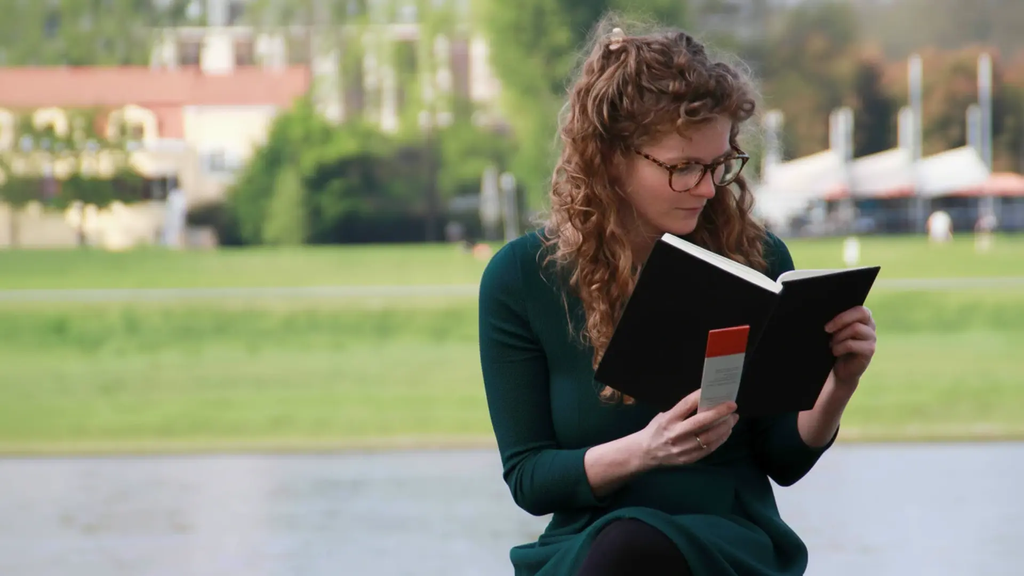

# Sarah

Ich lektoriere seit über fünf Jahren mit Leidenschaft wissenschaftliche Arbeiten, vor allem Abschlussarbeiten für Studierende. Dafür habe ich 2022 das Zertifikat „Freie Lektorin ADM“ erworben und bin Teil des Lektorierenden-Verband VfLL. Dabei arbeite ich mit Word-VBA-Makros, um meine Lektoratsprozesse effizienter zu gestalten und die Qualität meiner Arbeit zu gewährleisten.

Ich habe VWL und Politikwissenschaften studiert und bringe daher logisches Denken für das Lektorat mit. Es macht mir unglaublich Spaß, mich in Texte zu vertiefen und dazu beizutragen, dass die Arbeiten der Studierenden auf einem hohen Niveau präsentiert werden. Ich finde es toll zu sehen, wie viel Arbeit und Zeit Autorinnen und Autoren in ihren Text stecken und wie viel Wissen sie dabei zusammentragen.

Wenn Sie nach professioneller Unterstützung für Ihre wissenschaftliche Arbeit suchen, dann sind Sie bei mir richtig. Ich unterstütze Sie dabei, Ihre Arbeit auf ein höheres Niveau zu bringen, und stehe Ihnen mit Fachwissen und Erfahrung zur Seite.

# Sollen wir loslegen?

Schreiben Sie mir gerne, wenn Sie Fragen haben oder ein Angebot bekommen möchten. Ich freue mich darauf, Sie kennenzulernen und das Beste aus Ihrer Arbeit zu holen!

Schreiben Sie mir eine Mail!

[LinkedIn](https://www.linkedin.com/in/sarah-listabarth/) [VfLL](https://www.lektoren.de/profil/sarah-listabarth)